# Fitting Continuous Models Method of Moments & MLE Chapter 8

## This week in tgs data science

## Where we are going

| Transformation | F Known Analytic | F Known Simulation | F Unknown Simulation (bootstrap) | F Unknown Kernel density | F Unknown Method of Moments | F Unknown MLE | F Unknown Bayes |
| --- | --- | --- | --- | --- | --- | --- | --- |
| None | N/A | N/A | N/A | Soon | Today | Today | Soon |
| Mean | Soon |  |  | Soon | Soon | Soon | Soon |
| Median |  |  | Soon | Soon | Soon | Soon | Soon |
| Variance | Soon |  | Soon | Soon | Soon | Soon | Soon |
| Min |  |  | Soon | Soon | Soon | Soon | Soon |
| Max |  |  | Soon | Soon | Soon | Soon | Soon |

## Key question

\[ \text{Suppose } X \sim F_X \text{ where } F_X \text{ is unknown.}\\ \text{How might one estimate } F_X \text{ from } \boldsymbol{X}_N ?\]

## Key question

\[ \text{Suppose } X \sim F_X \text{ where } F_X \text{ is unknown.}\\ \text{How might one estimate } F_X \text{ from } \boldsymbol{X}_N ?\]

### Example

```r
data <- c(
-1.26,  4.05,  0.37, -1.43,  3.33, -0.14,  4.81,  0.44,  1.62,
 4.75,  3.13,  4.56,  0.20,  5.00,  0.47, -0.48,  4.14,  3.62,
 0.70,  3.92,  0.84,  0.38, -0.87,  1.05, -3.69,  0.24,  1.47,
-5.37,  3.24, -6.76, -3.20,  3.84,  2.57,  0.05, -0.35, -2.77,
 5.84,  2.98,  1.06, -0.20,  6.82,  4.52, -1.31,  0.74, -1.86,
 0.17,  0.25,  1.19, -0.11, -0.22
)
```

## ECDF

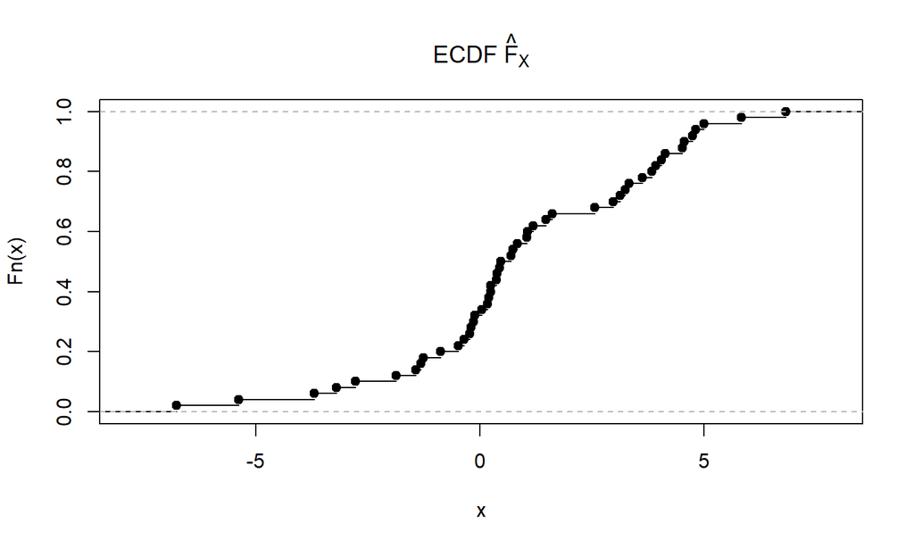

## The histogram

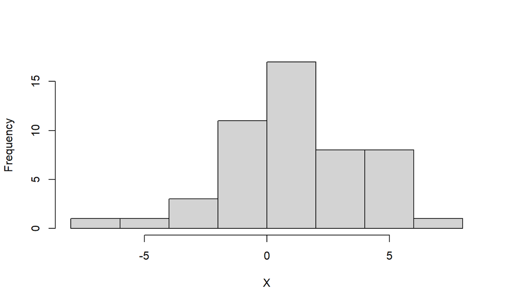

## TODAY

- Method of Moments
- MLE

## Method of Moments

1a. Choose a parametric distribution, \(F_X(x|\theta)\)

1b. Identify the distribution parameters, \(\theta\)

1. Calculate/find distribution **moments** (need as many moments as distribution parameters), \(E[X^k]\) or \(E[(X - E[X])^k]\)
2. Calculate sample moments.
3. Create system of equations equating distribution moments to sample moments.
4. Solve system of equations for distribution parameters.
5. \(\hat{F}_X = F_X(x | \theta = \hat{\theta})\)

## Method of Moments

### Example: BMI

```r
Hmisc::getHdata(nhgh)
bmi <- nhgh$bmi
```

## Method of Moments

**1a.** Choose a parametric distribution, \(F_X(x|\theta)\) \[X \sim \text{gamma}(\text{shape}, \text{scale})\]

**1b.** Identify the distribution parameters, \(\theta\) \[\theta = (\text{shape},\ \text{scale})\]

## Method of Moments

**2.** Calculate/find distribution **moments** (need as many moments as distribution parameters), \(E[X^k]\) or \(E[(X - E[X])^k]\) \[E[X] = \text{shape}*\text{scale}\] \[V[X] = \text{shape}*\text{scale}^2\]

## Method of Moments

**3.** Calculate sample moments.

```r
xbar <- mean(bmi) #28.32
s2 <- var(bmi)  #48.30
```

## Method of Moments

**4.** Create system of equations equating distribution moments to sample moments.

\[ \text{shape}*\text{scale} = \bar{X}\] \[ \text{shape}*\text{scale}^2 = s^2\]

## Method of Moments

**5.** Solve system of equations for distribution parameters. (In this example, we use the plug-in method.)

\[ \text{shape} = \frac{\bar{X}}{\text{scale}} \]

\[ \frac{\bar{X}}{\text{scale}}*\text{scale}^2 = s^2\]

\[ \text{scale} = \frac{s^2}{\bar{X}},\ \text{shape} = \frac{\bar{X}^2}{s^2}\]

## Method of Moments

```r
shape_hat <- xbar^2/s2 #16.6
scale_hat <- s2/xbar  #1.7
```

\[ \hat{\theta} = (\widehat{\text{shape}}= 16.6,\ \widehat{\text{scale}} = 1.7)\]

## Method of Moments

**6.** \(\hat{F}_X = F_X(x | \theta = \hat{\theta})\)

```r
Fbmi <- function(x){
pgamma(x, shape = shape_hat, scale = scale_hat)
}
```

## Method of Moments

```r
plot(ecdf(bmi))
curve(Fbmi(x), add = TRUE, col = "blue", lwd = 3, main = "BMI")
```

## Method of Moments

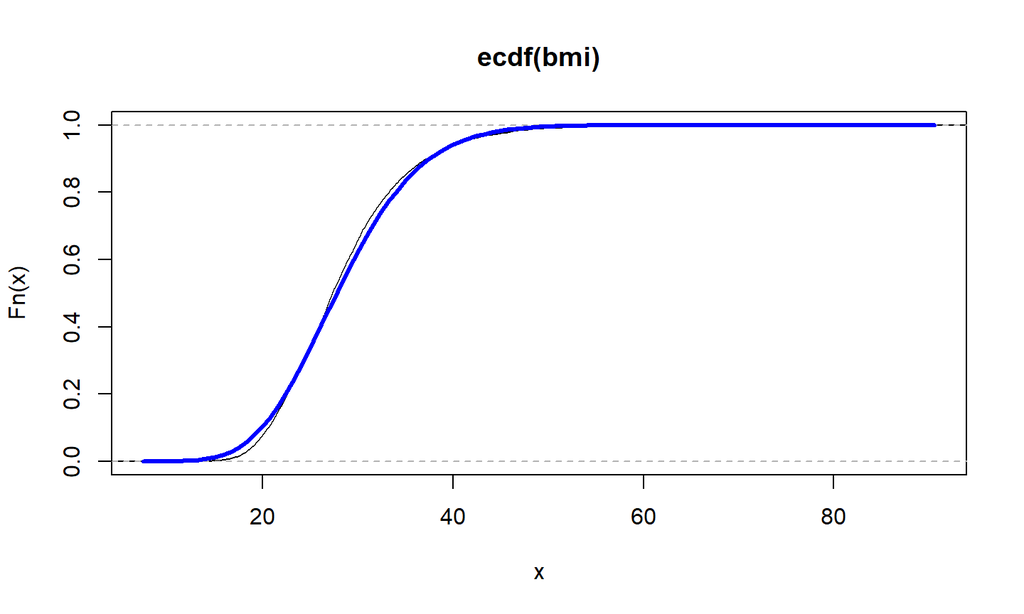

## Method of Moments

```r
fbmi <- function(x){dgamma(x, shape = shape_hat, scale = scale_hat)}
hist(bmi, freq = FALSE, main = "BMI")
curve(fbmi(x), add = TRUE, col = "blue", lwd = 3, main = "BMI")
```

[output not shown]

## Hands on

Estimate \(F_{\text{weight}}\) and \(f_{\text{weight}}\) from the NHANES dataset using the methods of moments. Generate plots of your estimates.

## Maximum likelihood

- Another, very commonly used method for estimating \(F_X\) and \(f_X\) from a sample of data.

## Maximum likelihood

If the distribution of \(X\) is known, then \[f_X(x |\ \theta)\] is the density function or the relative likelihood function.

The density function for a sample, \(\boldsymbol{X}_N\) is \[f_{\boldsymbol{X}_N}(\boldsymbol{x}|\ \theta) = \prod_{i=1}^N f_X(x_i|\ \theta)\]

## Maximum likelihood

In the usual setting, \(\theta\) is known. Now suppose that \(\boldsymbol{x}\) is known.

\[L(\theta|\ \boldsymbol{x}) = f_{\boldsymbol{X}_N}(\boldsymbol{x}|\ \theta)\]

This is the likelihood function.

## Maximum likelihood

Often, for mathematical ease, we actually work with the log likelihood function.

\[\ell(\theta|\ \boldsymbol{x}) = \log f_{\boldsymbol{X}_N}(\boldsymbol{x}|\ \theta) = \sum_{i=1}^N\log f_X(x_i|\ \theta)\]

## Maximum likelihood

### Example: BMI

For the sake of discussion, suppose that scale is known to be 1.7. (We’ll get to the multivariable setting later.)

```r
l <- function(shape, scale = 1.7, bmi){
  outer(shape, bmi, function(a,b)
    dgamma(
        x = b
      , shape = a
      , scale = 1.7
      , log = TRUE
    )
  ) %>% rowSums
}
```

## Maximum likelihood

### Example: BMI

```r
curve(l(x, 1.7, bmi), 0, 45, ylab = "", main = "log Likelihood", xlab = "shape")
```

## Maximum likelihood

### Example: BMI

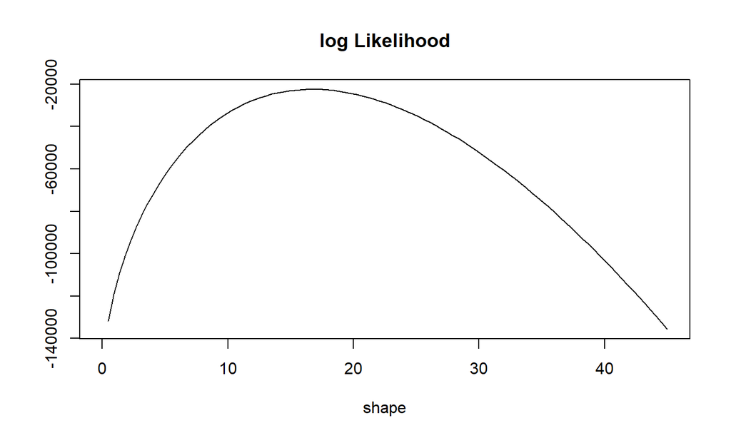

## Maximum likelihood

Note that the likelihood function is a function of the **unknown** parameter.

## Maximum likelihood

**Strategy:** Estimate the unknown parameter that maximizes the log likelihood.

**Why does maximizing the likelihood make sense?**

## Maximum likelihood

```r
curve(l(x, 1.7, bmi), 0, 45, ylab = "", main = "log Likelihood", xlab = "shape")
xxx <- seq(15,22,by = 0.01)
# Poor mans maximization
mle <- l(xxx, 1.7, bmi) %>%
  which.max %>%
  `[`(xxx, .)
abline(v = mle, col = "blue", lwd = 3)
```

## Maximum likelihood

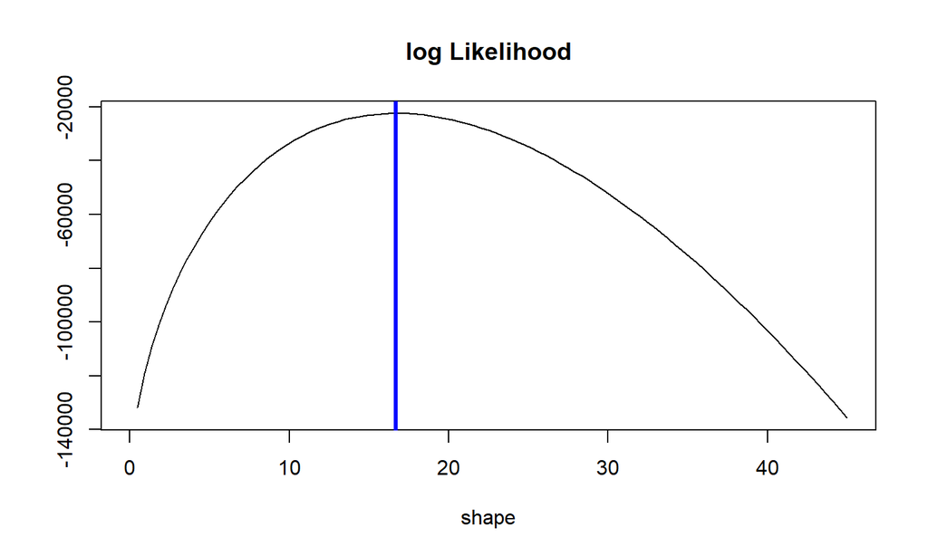

## Maximum likelihood

Will use the `optim` or `optimize` or `mle` function for maximization.

## Maximum likelihood

### Now consider MLE with the normal distribtuion

## Maximum likelihood

```r
require(stats4)
nLL <- function(mean, sd){
  fs <- dnorm(
        x = bmi
      , mean = mean
      , sd = sd
      , log = TRUE
    )
  -sum(fs)
}
fit <- mle(
    nLL
  , start = list(mean = 1, sd = 1)
  , method = "L-BFGS-B"
  , lower = c(0, 0.01)
)
par(mfrow = c(1,2)); plot(profile(fit), absVal = FALSE)
```

## Maximum likelihood

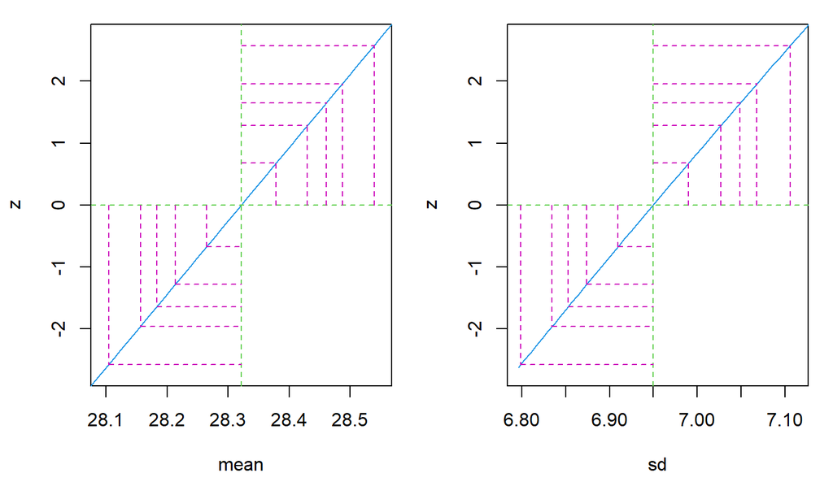

## Maximum likelihood

```r
par(mfrow = c(1,2))
plot(ecdf(bmi), main = "")
curve(
    pnorm(x, coef(fit)[1], coef(fit)[2])
  , add = TRUE
  , col = "blue"
  , lwd = 3
)
hist(bmi, freq = FALSE, main = "")
curve(
    dnorm(x, coef(fit)[1], coef(fit)[2])
  , add = TRUE
  , col = "blue"
  , lwd = 3
)
```

## Maximum likelihood

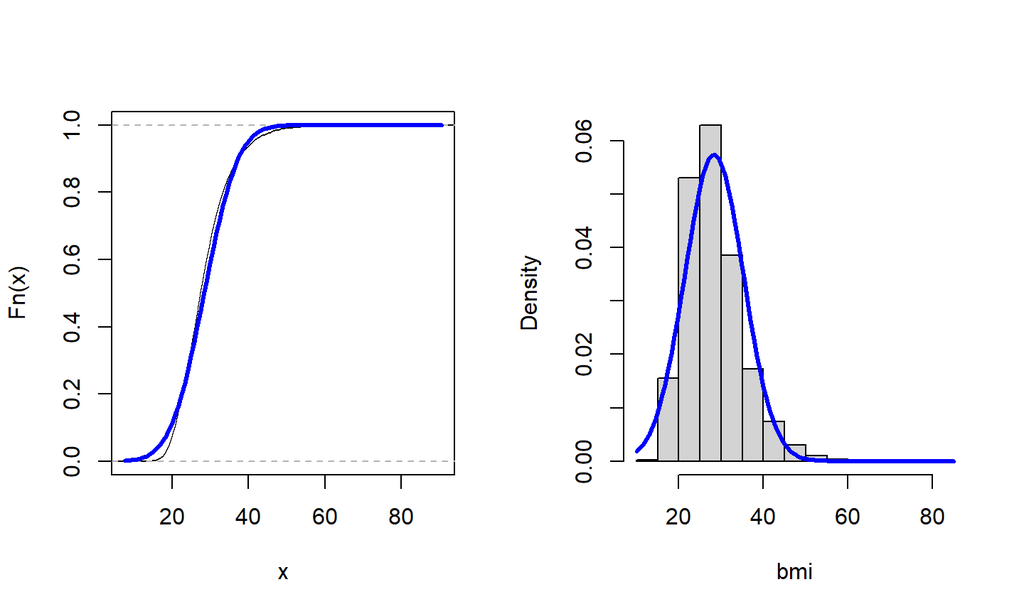

## Maximum likelihood with normal

Can use `lm` function to fit normal distribution, which is often easier.

```r
lm(bmi ~ 1) %>% summary
```

## Maximum likelihood with normal

```
##
## Call:
## lm(formula = bmi ~ 1)
##
## Residuals:
## Body Mass Index [kg/m^2]
##     Min      1Q  Median      3Q     Max
## -15.142  -4.892  -1.032   3.558  56.548
##
## Coefficients:
##             Estimate Std. Error t value Pr(>|t|)
## (Intercept) 28.32174    0.08431   335.9   <2e-16 ***
## ---
## Signif. codes:  0 '***' 0.001 '**' 0.01 '*' 0.05 '.' 0.1 ' ' 1
##
## Residual standard error: 6.95 on 6794 degrees of freedom
```

## Hands-on

Estimate the distribution of arm length using the method of maximum likelihood. Generate plots of the estimated CDF and PDF.

```r
Hmisc::getHdata(nhgh)
```

## Sampling from an \(\hat{F}_X\)

## Sampling from an \(\hat{F}_X\)

If we estimate \(\hat{F}_X\) with method of moments or maximum likelihood, we can directly use the `r` functions.

## Sampling from an \(\hat{F}_X\)

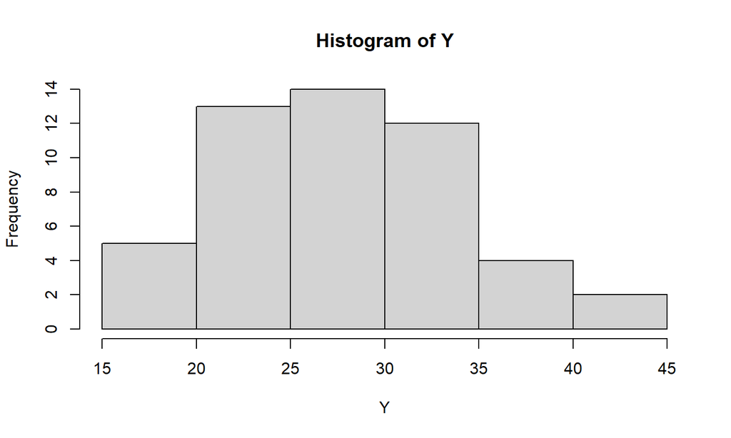

```r
# NORMAL MLE EXAMPLE WITH BMI
Y <- rnorm(50, coef(fit)[1], coef(fit)[2])
par(mfrow = c(1,1)); hist(Y)
```

## Sampling from an \(\hat{F}_X\)

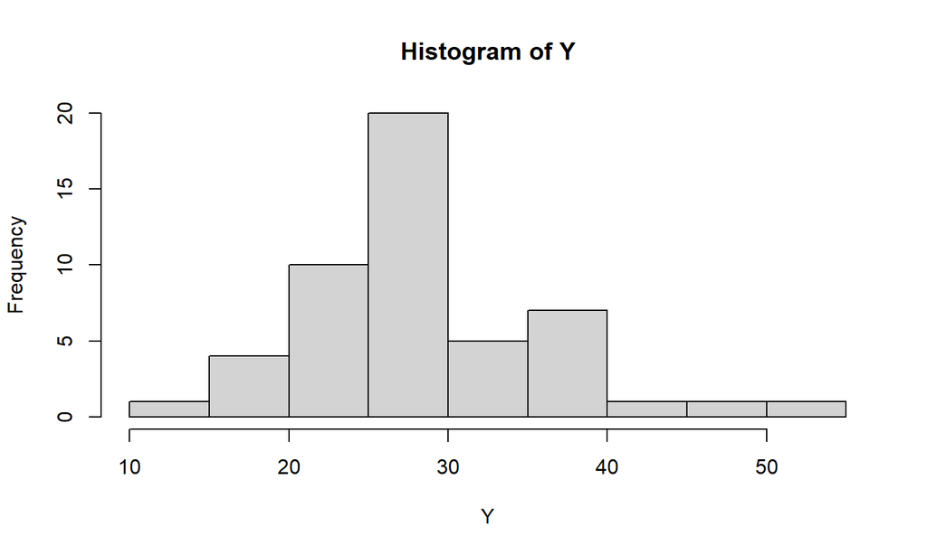

```r
# GAMMA MM EXAMPLE WITH BMI
Y <- rgamma(50, shape = shape_hat, scale = scale_hat)
hist(Y)
```

## Sampling from an \(\hat{F}_X\)

What about \(\hat{F}_X\) estimated with a kernel density estimation?

## Sampling from an \(\hat{F}_X\)

What about \(\hat{F}_X\) estimated with a kernel density estimation?

### New tool: sampling with the `q` function

If an inverse of the CDF exists (the `q` function), then we can sample from the distribution by

1. Sample from a uniform distribution
2. Plug-in the samples to the `q` function

## Sampling with the `q` function

```r
U <- runif(1000)
Y <- qnorm(U)
qqnorm(Y)
abline(0,1)
```

## Sampling with the `q` function

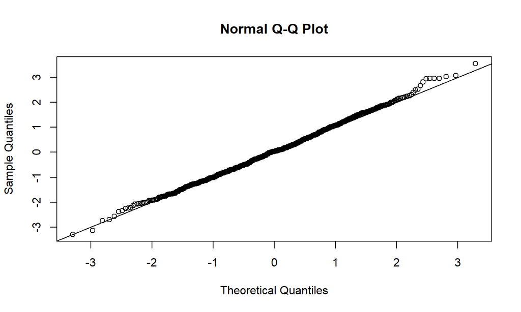

## Sampling with the `q` function

```r
U <- runif(1000)
Y <- qweibull(U, shape = 3, scale = 1.2)
ps <- ppoints(1000)
theoretical <- qweibull(ps, shape = 3, scale = 1.2)
sample <- quantile(Y, ps)
plot(theoretical, sample)
abline(0,1)
```

## Sampling with the `q` function

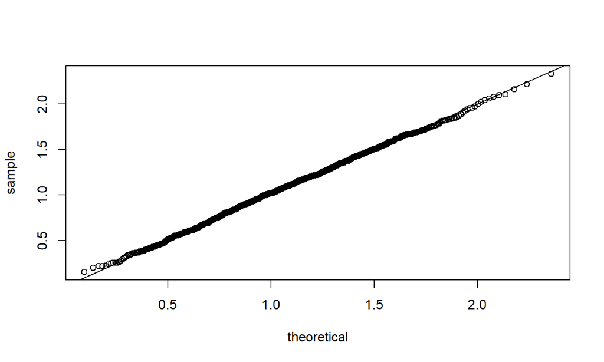

## Sampling from a KDE of \(\hat{F}_X\)

*Key idea:* A kernel density estimate with the gaussian kernel has a well defined `q` function.

- We can write the `q` function using the the uniroot method.
- We can approximate with a lookup table.

```r
ecdfstar <- function(t, data, smooth){
  outer(t, data, function(a,b){ pnorm(a, b, smooth)}) %>% rowMeans
}
```

## Sampling from a KDE of \(\hat{F}_X\)

### Approximate with a lookup table.

```r
tbl <- data.frame(
    x = seq(10,100,by = 0.01)
)
tbl$p <- ecdfstar(tbl$x, bmi, 0.5)
tbl <- tbl[!duplicated(tbl$p),]

qbmi <- function(ps, tbl){
  rows <- cut(ps, tbl$p, labels = FALSE)
  tbl[rows, "x"]
}
```

## Sampling from a KDE of \(\hat{F}_X\)

### Approximate with a lookup table.

```r
U <- runif(1000)
Y <- qbmi(U, tbl)
qqplot(bmi, Y)
abline(0,1)
```

## Sampling from a KDE of \(\hat{F}_X\)

### Approximate with a lookup table.

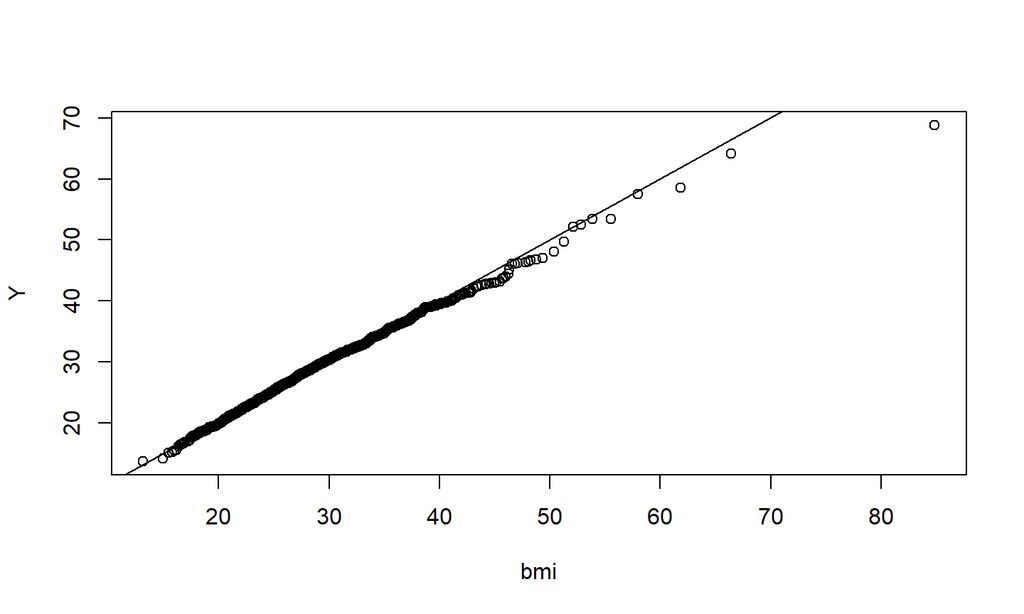

## Hands on

Create a `q` function and sample from it for the `f4` distribution from deliverable 5.

```r
rf4 <- function(N){
  G <- sample(0:1, N, replace = TRUE)
  (G==0)*rbeta(N,5,1) + (G==1)*rbeta(N,1,5)
}
```